# Assignment_1

Gavin Jones

2026-09-12

## This assignment used a Sports Engagement Dataeet from Kaggle from Vision Langai. The dataset contains roughly 50,000 observations and 14 variables that capture interactions with sports. The quentattive variables for this dataset include age, television hours watched, social media sports time, and engagement score. The categorical variables for this are gender, education level, sport type, and engagement type.

## https://www.kaggle.com/datasets/visionlangai/sports-engagement-dataset?resource=download

## Load the Dataset

```r
sports <- read.csv("~/Downloads/Sports Engagement.csv")

head(sports)
```

```
##   Age Gender Education_Level Sport_Type Stadium_Attendance_Per_Month
## 1  54 Female     High School Basketball                            1
## 2  44 Female             PhD   Football                            0
## 3  30 Female        Bachelor     Tennis                            4
## 4  58 Female          Master     Tennis                            2
## 5  23   Male     High School     Tennis                            4
## 6  36   Male          Master     Hockey                            0
##   TV_Watching_Hours_Per_Week Newspaper_Sports_Read_Per_Week
## 1                       5.63                              2
## 2                       5.42                              1
## 3                       5.46                              1
## 4                       3.62                              0
## 5                       0.27                              0
## 6                       5.24                              0
##   Social_Media_Sports_Time_Per_Day Streaming_Platform_Use Fantasy_Sports_Play
## 1                             0.04                      0                   0
## 2                             4.81                      1                   1
## 3                             3.09                      0                   0
## 4                             1.24                      0                   1
## 5                             0.89                      1                   1
## 6                             0.10                      1                   0
##   Esports_Viewing Mobile_App_Sports_Usage Engagement_Score Engagement_Type
## 1               0                       0               31     Traditional
## 2               0                       0               61          Modern
## 3               0                       1               68     Traditional
## 4               1                       0               44     Traditional
## 5               0                       1               55          Modern
## 6               1                       0               37     Traditional
```

## Numerical Variables

```r
summary (sports$Age)
```

```
##    Min. 1st Qu.  Median    Mean 3rd Qu.    Max.
##   16.00   28.00   40.00   39.99   52.00   64.00
```

```r
summary (sports$TV_Watching_Hours_Per_Week)
```

```
##    Min. 1st Qu.  Median    Mean 3rd Qu.    Max.
##   0.000   1.500   3.000   3.004   4.510   6.000
```

```r
summary (sports$Engagement_Score)
```

```
##    Min. 1st Qu.  Median    Mean 3rd Qu.    Max.
##    0.00   48.00   60.00   59.46   71.00  100.00
```

```r
mean(sports$Age)
```

```
## [1] 39.99182
```

```r
sd (sports$Age)
```

```
## [1] 14.11014
```

```r
mean (sports$Engagement_Score)
```

```
## [1] 59.46072
```

## Categorical Variables

```r
table(sports$Gender)
```

```
##
## Female   Male
##  25121  24879
```

```r
table(sports$Sports_Type)
```

```
## < table of extent 0 >
```

```r
table(sports$Engagement_Type)
```

```
##
##      Hybrid      Modern Traditional
##       10228       11908       27864
```

```r
table(sports$Education_Level)
```

```
##
##    Bachelor High School      Master         PhD
##       12584       12612       12448       12356
```

## The datset is split almost evenly between male and female responses. The most common engagement type is Traditional, and education level is veryc similar all around with all degree types having roughly 12,000 respondants each.

```r
sports$Age_Group <- ifelse (sports$Age < 30, "Under 30",
                            ifelse(sports$Age < 50, "30-49", "50 and Older"))

table (sports$Age_Group)
```

```
##
##        30-49 50 and Older     Under 30
##        20553        15267        14180
```

## With this I made the Quantatative Variable of Age into a Categorical Variable of Age using 3 different groups being “Under 30”, “30-49”, and “50 and older.” With this transformation it will be easier to compare the engagement across different age ranges.

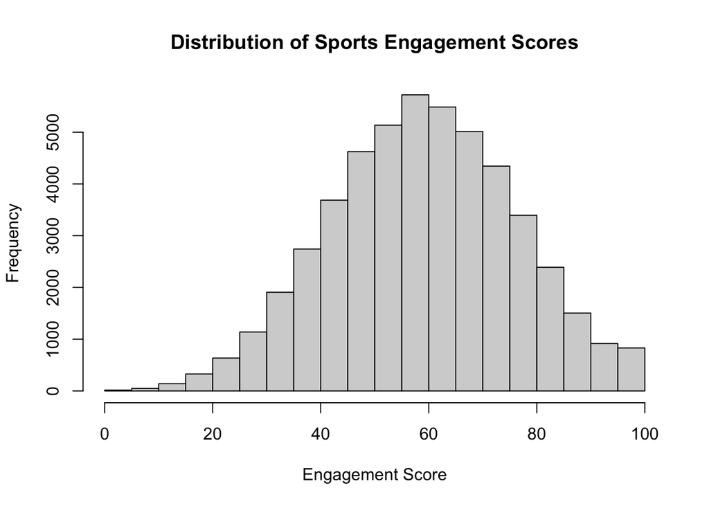

```r
hist (sports$Engagement_Score,
      main = "Distribution of Sports Engagement Scores",
      xlab = "Engagement Score")
```

## This graph shows the distribution of sports engagement scores among the respondants. It allows viewers to see where engagement scores are most common and any super high or low scores. ## Based on the graph most people seem to score between 40 and 80 on engagement with the nmost being right around 55.

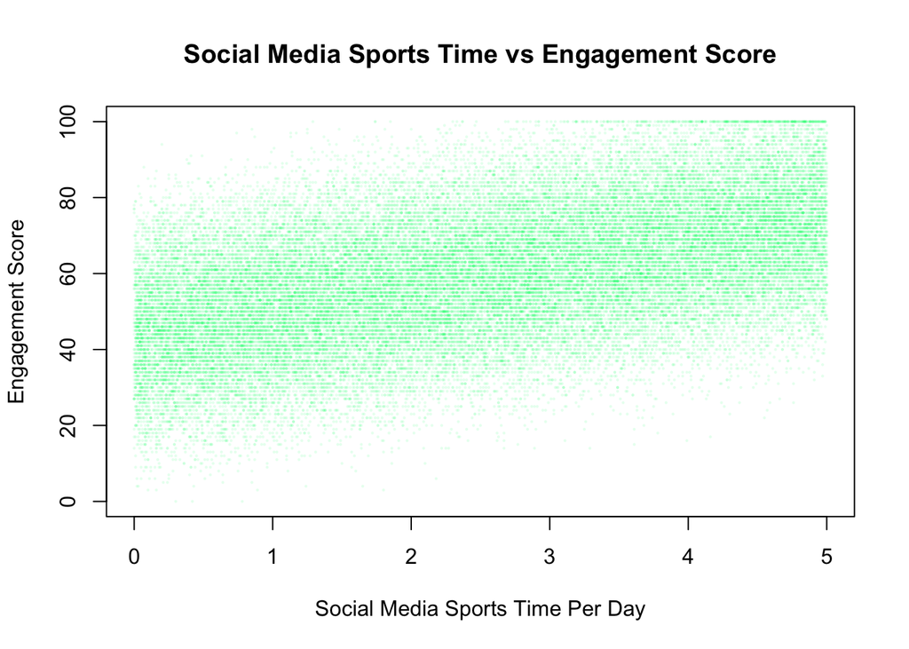

```r
plot (sports$Social_Media_Sports_Time_Per_Day,
      sports$Engagement_Score,
      main = "Social Media Sports Time vs Engagement Score",
      xlab = "Social Media Sports Time Per Day",
      ylab = "Engagement Score",
      pch = 16,
      cex = 0.3,
      col = rgb (0, 1, 0.5, 0.12))
```

## This plot explains whether spending more time on Sports Media actually relates to a higher overall engagement score or not. ## This plot shows that there is a coorelation between time spent on sports social media and a higher engagement score, as the graph showcased a slight upward trend to the right progressively.